# Noise Analysis 20-1000 Hz

# Fun with Maps

```
[1] "Urban" "Rural"
```

Sites are randomly distributed across Lincoln, Nebraska (urban) and into the surrounding rural area (rural).

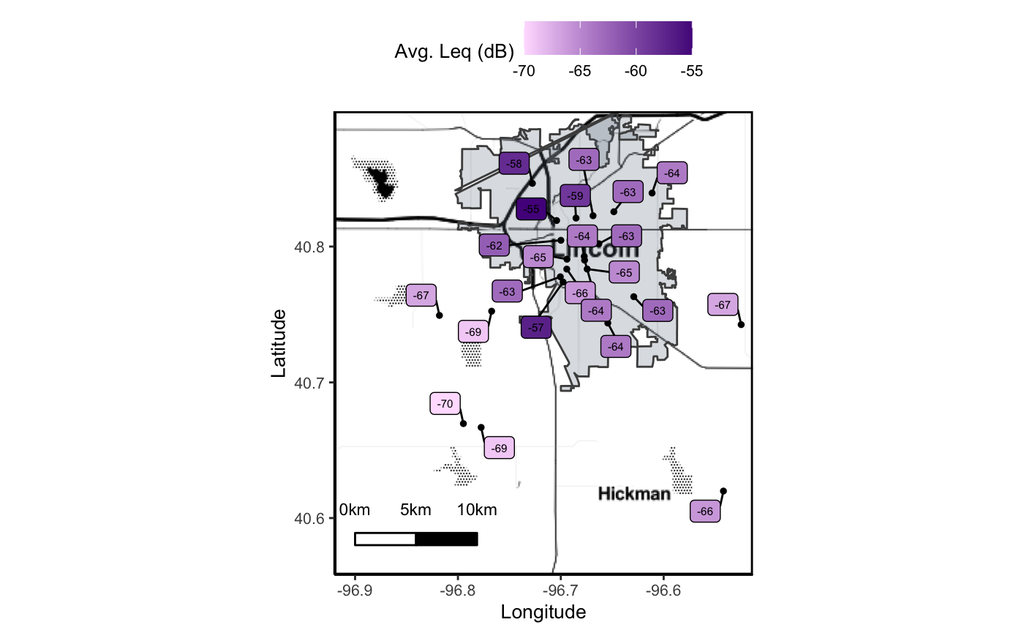

Site averages vary from -55 dB to -70 dB (~15 dB difference). The sites with the highest Leq appear to occur near highly traveled roads (i.e., highways/interstates).

# Spatial Variation in Vibratory Noise

Does vibratory noise vary over space?

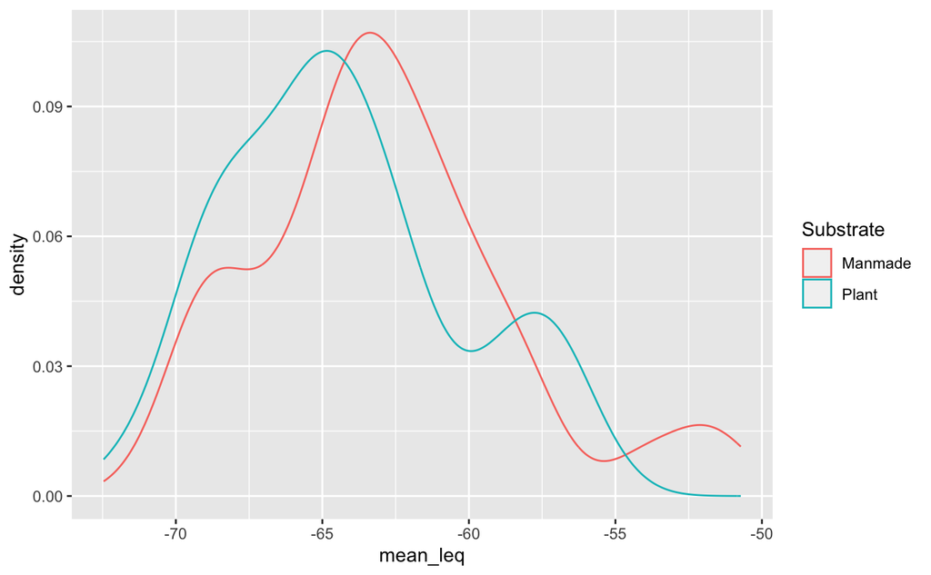

```
[1] 179 276
```

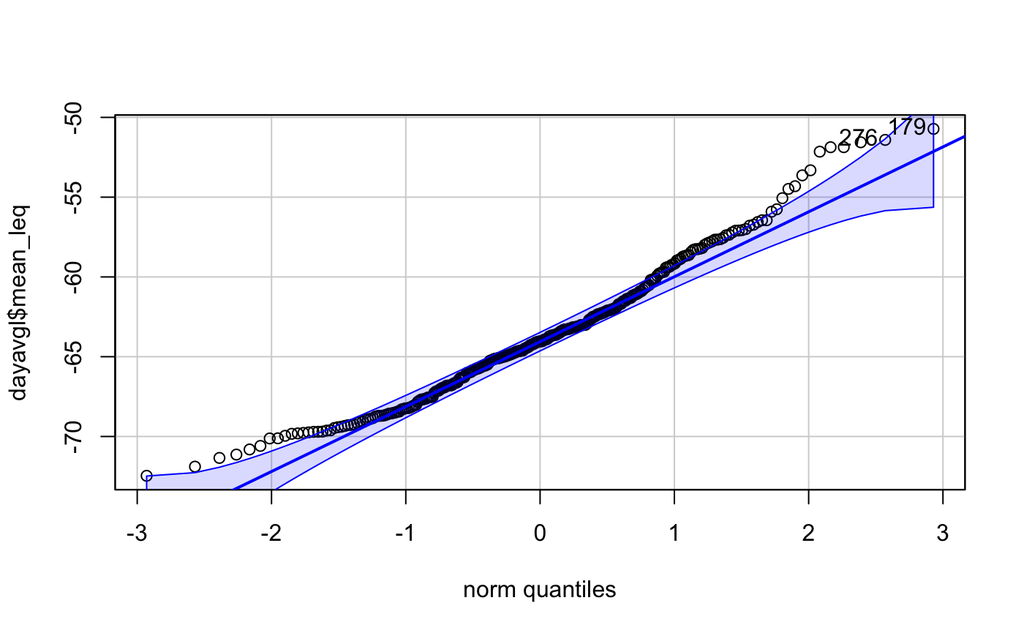

```
[1] 179 276
```

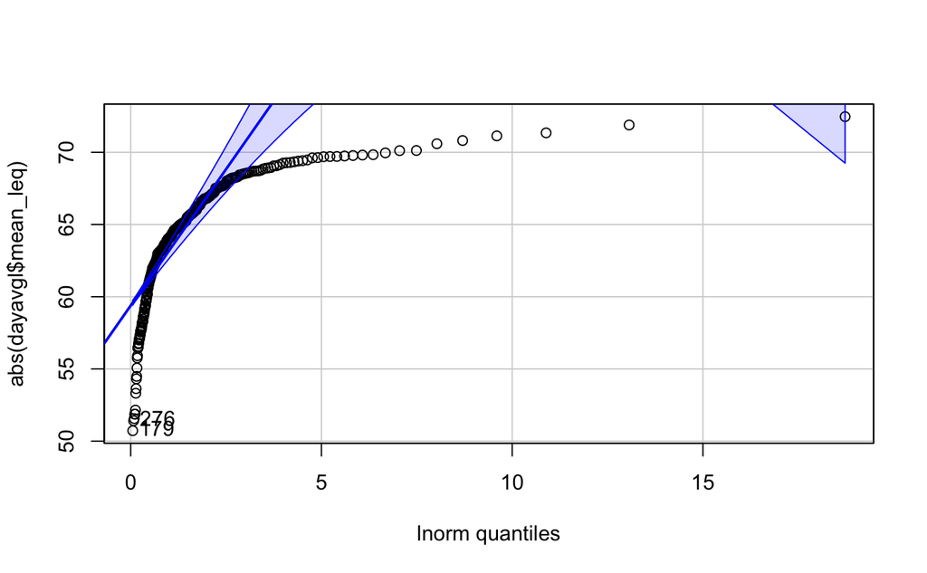

```
[1] 179 276
```

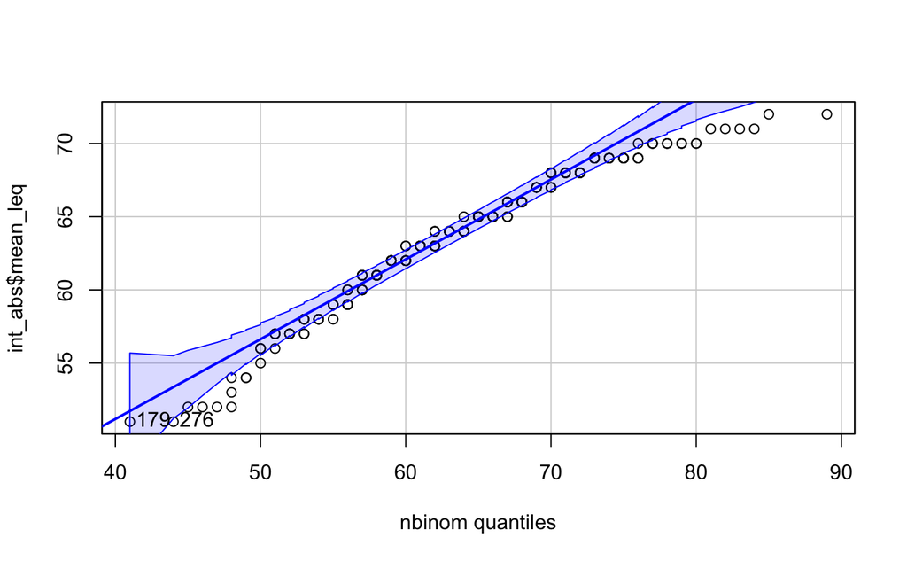

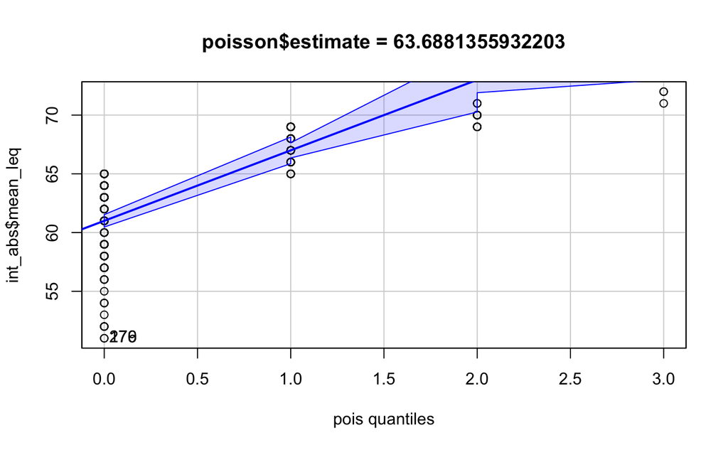

```
[1] 179 276
```

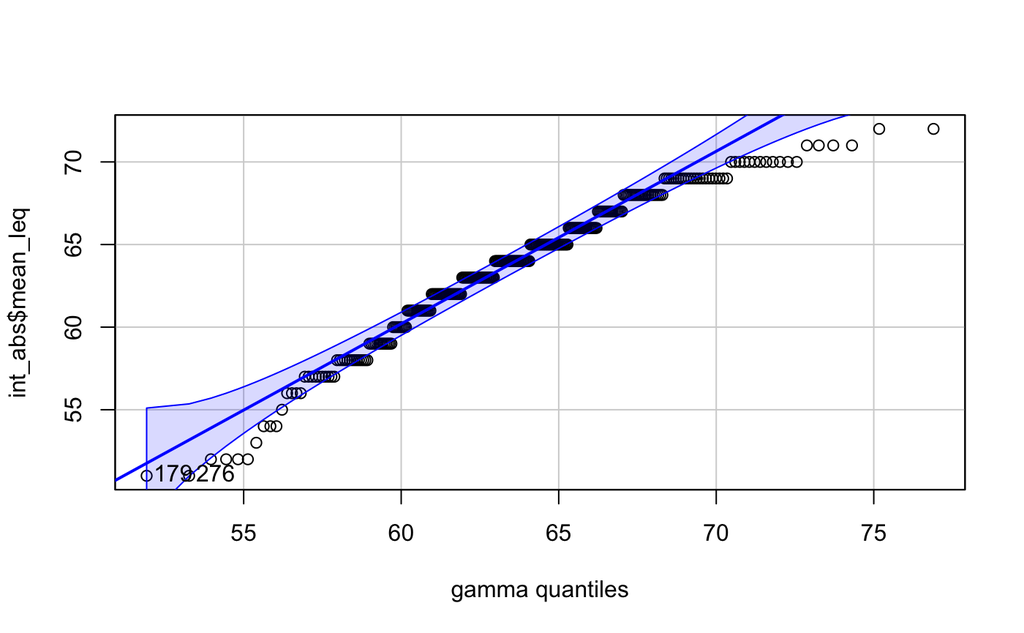

```
Call:
lm(formula = mean_leq ~ Dim.1 + Substrate, data = dayavgl)

Residuals:
    Min      1Q  Median      3Q     Max
-5.8973 -2.0326 -0.6681  1.2541 11.3621

Coefficients:
               Estimate Std. Error  t value Pr(>|t|)
(Intercept)    -62.9883     0.2729 -230.844  < 2e-16 ***
Dim.1            1.5781     0.1038   15.209  < 2e-16 ***
SubstratePlant  -1.2127     0.3671   -3.303  0.00107 **
---
Signif. codes:  0 ‘***’ 0.001 ‘**’ 0.01 ‘*’ 0.05 ‘.’ 0.1 ‘ ’ 1

Residual standard error: 3.135 on 292 degrees of freedom
Multiple R-squared:  0.4556,    Adjusted R-squared:  0.4518
F-statistic: 122.2 on 2 and 292 DF,  p-value: < 2.2e-16
```

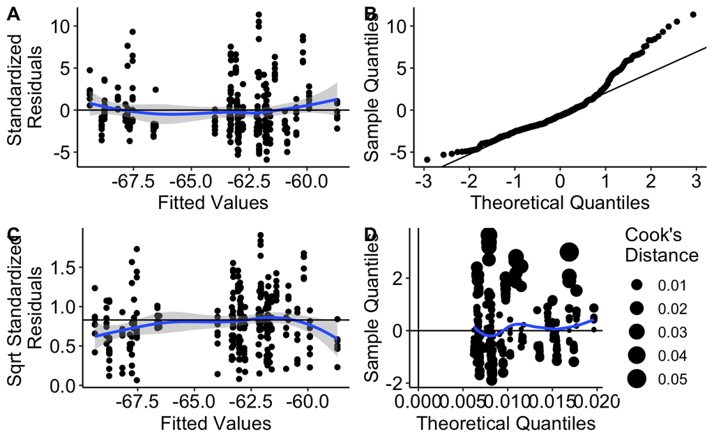

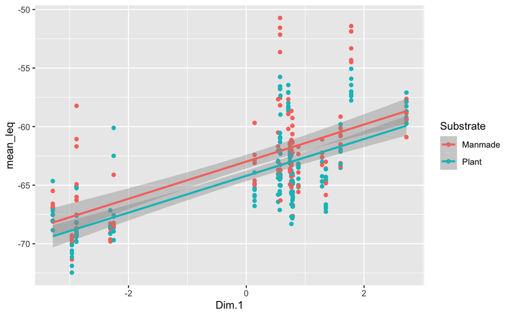

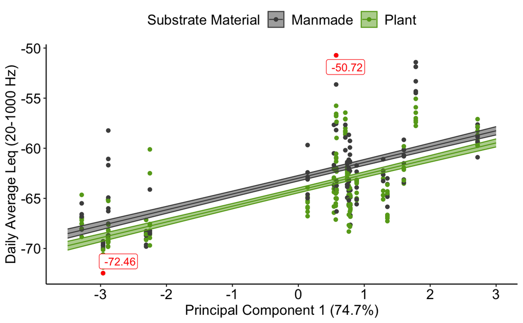

Daily average Leq has a significant positive relationship with Principal Component 1 - road vibratory noise (t = 15.209, df = 292, P < 0.001, adj.R^2 = 0.4518). Daily average Leq was significantly higher on manmade material than plant material (t = -3.303, df = 292, P = 0.001).

Let’s take a closer look at the substrate. Manmade structures - Paneling, Metal, Concrete, Brick, Wood Plant structures - Herb, Tree, Shrub, Vine

[output not shown]

# Temporal Variation in Vibratory Noise

## Season

```
NOTE: Results may be misleading due to involvement in interactions
```

```
$`emmeans of Visit`
 Visit emmean    SE   df lower.CL upper.CL
 1      -65.5 0.650 27.1    -66.8    -64.2
 2      -65.8 0.634 24.5    -67.1    -64.5
 3      -64.6 0.643 25.9    -65.9    -63.3
 4      -65.2 0.631 24.0    -66.5    -63.9

Results are averaged over the levels of: Category
Degrees-of-freedom method: kenward-roger
Confidence level used: 0.95

$`pairwise differences of Visit`
 1               estimate    SE  df t.ratio p.value
 Visit1 - Visit2    0.279 0.392 242   0.711  0.8927
 Visit1 - Visit3   -0.867 0.407 242  -2.129  0.1468
 Visit1 - Visit4   -0.260 0.387 242  -0.671  0.9081
 Visit2 - Visit3   -1.146 0.382 241  -3.002  0.0156
 Visit2 - Visit4   -0.539 0.360 241  -1.498  0.4401
 Visit3 - Visit4    0.607 0.376 241   1.614  0.3728

Results are averaged over the levels of: Category
Degrees-of-freedom method: kenward-roger
P value adjustment: tukey method for comparing a family of 4 estimates
```

To investigate whether noise varied across the season, we used a linear mixed model with visit number and category, and their interaction with site as a random factor. There was a trend that daily average Leq varied across the 2020 season (Chisq = 7.362, df = 265, P = 0.061, Conditional R^2 = 0.753). A post hoc test suggests that visit 3 was significantly louder than visit 2 (t = -3.002, P = 0.016). Also, urban areas are louder than rural areas (Chisq = 20.494, P < 0.001). There is no interaction between visit and category (Chisq = 3.493, P = 0.322).

Let’s look at date rather than visit.

```
Analysis of Deviance Table (Type II Wald chisquare tests)

Response: mean_leq
               Chisq Df Pr(>Chisq)
Day           1.5565  1     0.2122
Category     21.2343  1  4.064e-06 ***
Day:Category  1.8131  1     0.1781
---
Signif. codes:  0 ‘***’ 0.001 ‘**’ 0.01 ‘*’ 0.05 ‘.’ 0.1 ‘ ’ 1
Anova Table (Type II tests)

Response: mean_leq
              Sum Sq  Df  F value Pr(>F)
Day            13.13   1   1.4035 0.2372
Category     1675.89   1 179.0920 <2e-16 ***
Day:Category    4.13   1   0.4412 0.5071
Residuals    2470.43 264
---
Signif. codes:  0 ‘***’ 0.001 ‘**’ 0.01 ‘*’ 0.05 ‘.’ 0.1 ‘ ’ 1
RStudioGD
        4
```

We see similar results, but with no difference over time (F = 1.404, df = 264, P = 0.237, Adj. R^2 = 0.398).

```r
harvest_Lan <- readRDS("data/harvest_Lan.rds")

dayavgl_20_rural <- dayavgl_20 %>%
  filter(Category == "Rural") %>%
  mutate(mean_harvest = ifelse(Date < "2020-08-31", 0,
                               ifelse(Date < "2020-09-06", 1,
                                      ifelse(Date < "2020-09-13", 2.5,
                                             ifelse(Date < "2020-09-20", 6.5,
                                                    ifelse(Date < "2020-09-27", 11.5,
                                                           ifelse(Date < "2020-10-04", 16.5,
                                                                  ifelse(Date < "2020-10-11", 20,
                                                                         ifelse(Date < "2020-10-18", 17,
                                                                                ifelse(Date < "2020-10-25", 11.5))))))))))

ggplot(aes(x = mean_harvest, y = mean_leq), data = dayavgl_20_rural) +
  geom_point() +
  geom_smooth(method = "lm")

harvest.lm <- lm(mean_leq ~ mean_harvest, data = dayavgl_20_rural)
summary(harvest.lm)
```

[output not shown]

```
Call:
lm(formula = mean_leq ~ mean_harvest, data = dayavgl_20_rural)

Residuals:
    Min      1Q  Median      3Q     Max
-3.9015 -1.5081 -0.5335  1.0104  9.6279

Coefficients:
             Estimate Std. Error  t value Pr(>|t|)
(Intercept)  -68.6992     0.4976 -138.065   <2e-16 ***
mean_harvest   0.0733     0.0417    1.758   0.0828 .
---
Signif. codes:  0 ‘***’ 0.001 ‘**’ 0.01 ‘*’ 0.05 ‘.’ 0.1 ‘ ’ 1

Residual standard error: 2.475 on 76 degrees of freedom
Multiple R-squared:  0.03906,   Adjusted R-squared:  0.02641
F-statistic: 3.089 on 1 and 76 DF,  p-value: 0.08285
```

```r
harvest.lmer <- lmer(mean_leq ~ mean_harvest + (1 | Site), data = dayavgl_20_rural)
summary(harvest.lmer)
```

```
Linear mixed model fit by REML ['lmerMod']
Formula: mean_leq ~ mean_harvest + (1 | Site)
   Data: dayavgl_20_rural

REML criterion at convergence: 344.8

Scaled residuals:
    Min      1Q  Median      3Q     Max
-1.7332 -0.5890 -0.1364  0.2263  3.9614

Random effects:
 Groups   Name        Variance Std.Dev.
 Site     (Intercept) 2.247    1.499
 Residual             4.038    2.010
Number of obs: 78, groups:  Site, 6

Fixed effects:
              Estimate Std. Error t value
(Intercept)  -68.70767    0.73442 -93.554
mean_harvest   0.07204    0.03397   2.121

Correlation of Fixed Effects:
            (Intr)
mean_harvst -0.456
```

```r
Anova(harvest.lmer)
```

```
Analysis of Deviance Table (Type II Wald chisquare tests)

Response: mean_leq
              Chisq Df Pr(>Chisq)
mean_harvest 4.4975  1    0.03394 *
---
Signif. codes:  0 ‘***’ 0.001 ‘**’ 0.01 ‘*’ 0.05 ‘.’ 0.1 ‘ ’ 1
```

```r
r.squaredGLMM(harvest.lmer)
```

```
            R2m       R2c
[1,] 0.03639155 0.3808811
```

```r
predictions <- expand.grid(mean_harvest = seq(0, 20, 0.2))
predictions$response <- predict(harvest.lmer, newdata = predictions, se.fit = TRUE, re.form = NA, type = "response")
myFunc <- function(mm) {
    predict(mm, newdata = predictions, re.form = ~0, type = "response")
}
#bigBoot_harvest <- bootMer(harvest.lmer, myFunc, nsim = 1000)
#saveRDS(bigBoot_harvest, file = "data/bigBoot_harvest.Rds")
bigBoot_harvest <- readRDS("data/bigBoot_harvest.Rds")
predSE <- t(apply(bigBoot_harvest$t, MARGIN = 2, FUN = sd))
predictions$SE <- predSE[1, ]

harvest <- ggplot() +
  geom_point(aes(x = mean_harvest, y = mean_leq), data = dayavgl_20_rural, color = "#1B9E77") +
  geom_line(aes(x = mean_harvest, y = response), data = predictions, size = 1) +
  geom_ribbon(aes(x = mean_harvest, ymax = response + SE, ymin = response - SE), data = predictions, color = "#1B9E77", fill = "#1B9E77", alpha = 0.5) +
  xlab("Week End Percent of Field Crop Harvested") +
  ylab("Daily Average Leq (20-1000 Hz)") +
  theme_classic() +
  theme(text = element_text(size = 14, color = "black"),
        axis.text = element_text(size = 14, color = "black"),
        axis.title = element_text(size = 14, color = "black"),
        legend.text = element_text(size = 14, color = "black"),
        legend.position = "none")

jpeg("figures/harvest.jpeg", 4, height = 4, units = "in", quality = 100, res = 300)
```

```r
print(harvest)
dev.off()
```

```r
harvest
```

[output not shown]

We used USDA data on week end percent harvest in 2020 for field crops in Nebraska. This gave details on oats, wheat, dry beans, sorghum, corn, and soybeans. We restricted this list to corn and soybeans, as these are the major crops grown and harvested in Lancaster County, Nebraska. We took the mean week end percent harvested of these two crops during the study season and compared these to the rural recorded vibratory noise levels. The week end percent harvested was positively correlated with the daily average Leq for rural sites (Chisq = 4.4975, P = 0.034, conditional R^2 = 0.381).

## 24 Hours